# Taller: ¿Un número o varios?

El resumen para la Gerencia de Riesgo de Crédito · Componentes principales I

Oscar Manuel Contreras Gacha (20221020052)

Juan Pablo Sarmiento Ramírez (20221020138)

Steven Navarro Parrales (20221020048)

Juan Diego Grajales Castillo (20221020128)

Estadística Multidimensional · 26158 · grupo 020-81 · periodo 2026-3

Cada resultado se lee con tres frases:

- 👀 **Qué vemos**: el número o el gráfico, sin interpretar.
- 💼 **Qué significa para el cliente**: la traducción a la cartera de tarjetas.
- ✅ **Qué decide el cliente**: la consecuencia práctica.

El taller parte de lo que dejó listo el Módulo 11 de `Entrega/analisis_synthetic_credit_card.Rmd`: las mismas variables **retenidas**, los montos con logaritmo (`log(x+1)`, para las variables con asimetría mayor que 1) para que unos pocos clientes enormes no manden, y todo en la misma escala (`scale()`). `Payment_Ratio` y `Credit_Utilization` quedan **aparte**: no se usan para armar el resumen, pero sirven para entenderlo después.

A lo largo del taller, una **componente** (principal) es una suma con pesos de las variables de la ficha. La primera es la que más información guarda de la ficha; la segunda, lo más que queda, y así.

# 1 El encargo

```r
credit <- read.csv("data/bronze/synthetic_credit_card_customer_behavior_dataset.csv",
                   stringsAsFactors = FALSE)

vars <- c("Annual_Income", "Credit_Limit", "Statement_Balance", "Payment_Amount",
          "EMI_Count", "Monthly_Transactions", "Avg_Transaction_Value",
          "International_Transactions", "Credit_Score")
suplementarias <- c("Payment_Ratio", "Credit_Utilization")

etiqueta <- c(Annual_Income = "Ingreso anual", Credit_Limit = "Cupo",
              Statement_Balance = "Saldo facturado", Payment_Amount = "Monto pagado",
              EMI_Count = "Compras a cuotas", Monthly_Transactions = "Compras al mes",
              Avg_Transaction_Value = "Valor por compra",
              International_Transactions = "Compras internacionales",
              Credit_Score = "Puntaje crediticio",
              Payment_Ratio = "Proporción pagada", Credit_Utilization = "Uso del cupo")

c(clientes = nrow(credit), variables_activas = length(vars),
  celdas_vacias = sum(is.na(credit[vars])))
```

```
##          clientes variables_activas     celdas_vacias
##             50000                 9                 0
```

**El cliente es la Gerencia de Riesgo de Crédito del banco emisor** de las 50 000 tarjetas de la base (rupias indias, ₹). Cada mes **decide qué clientes entran al programa de seguimiento preventivo** (llamada del gestor, congelar los aumentos de cupo y ofrecer refinanciación antes de la mora), y hoy lo hace con una ficha de **9 variables numéricas** por cliente; quiere saber si puede reemplazarla por un solo número. Escogimos esas 9 entre las 21 retenidas del Módulo 11 porque responden las preguntas de un analista de riesgo: cuánto puede (`Annual_Income`, `Credit_Limit`), cuánto debe y paga (`Statement_Balance`, `Payment_Amount`), cómo usa la tarjeta (`Monthly_Transactions`, `Avg_Transaction_Value`, `EMI_Count`, `International_Transactions`) y qué dice el buró (`Credit_Score`). Dejamos por fuera las siete categorías de gasto, que dicen en qué gasta el cliente y no cambian su riesgo; `Cash_Advance_Amount`, que tiene al 70 % de los clientes en cero (Módulo 4); y la edad, la antigüedad de la tarjeta, la app y los puntos redimidos, que no hacen parte de la decisión. La base no tiene celdas vacías (Módulo 2), así que entran los 50 000 clientes.

```r
skew <- function(x) mean(((x - mean(x)) / sd(x))^3)   # la misma función del Módulo 11
asimetria <- sapply(credit[vars], skew)
con_log <- vars[abs(asimetria) > 1]

X <- credit[vars]
X[con_log] <- lapply(X[con_log], log1p)

data.frame(variable = etiqueta[vars], asimetria = round(asimetria, 2),
           transformacion = ifelse(vars %in% con_log, "log(x+1) + scale()", "scale()"))
```

|  | variable | asimetria | transformacion |
| --- | --- | --- | --- |
| Annual_Income | Ingreso anual | 2.55 | log(x+1) + scale() |
| Credit_Limit | Cupo | 3.01 | log(x+1) + scale() |
| Statement_Balance | Saldo facturado | 3.80 | log(x+1) + scale() |
| Payment_Amount | Monto pagado | 4.20 | log(x+1) + scale() |
| EMI_Count | Compras a cuotas | 0.17 | scale() |
| Monthly_Transactions | Compras al mes | 0.54 | scale() |
| Avg_Transaction_Value | Valor por compra | 3.90 | log(x+1) + scale() |
| International_Transactions | Compras internacionales | 2.11 | log(x+1) + scale() |
| Credit_Score | Puntaje crediticio | -0.58 | scale() |

La tabla muestra qué variables tienen cola larga (asimetría mayor que 1): esas entran en logaritmo y las demás solo se estandarizan, para que unos pocos clientes enormes no manden el resumen.

# 2 ¿Se repiten?

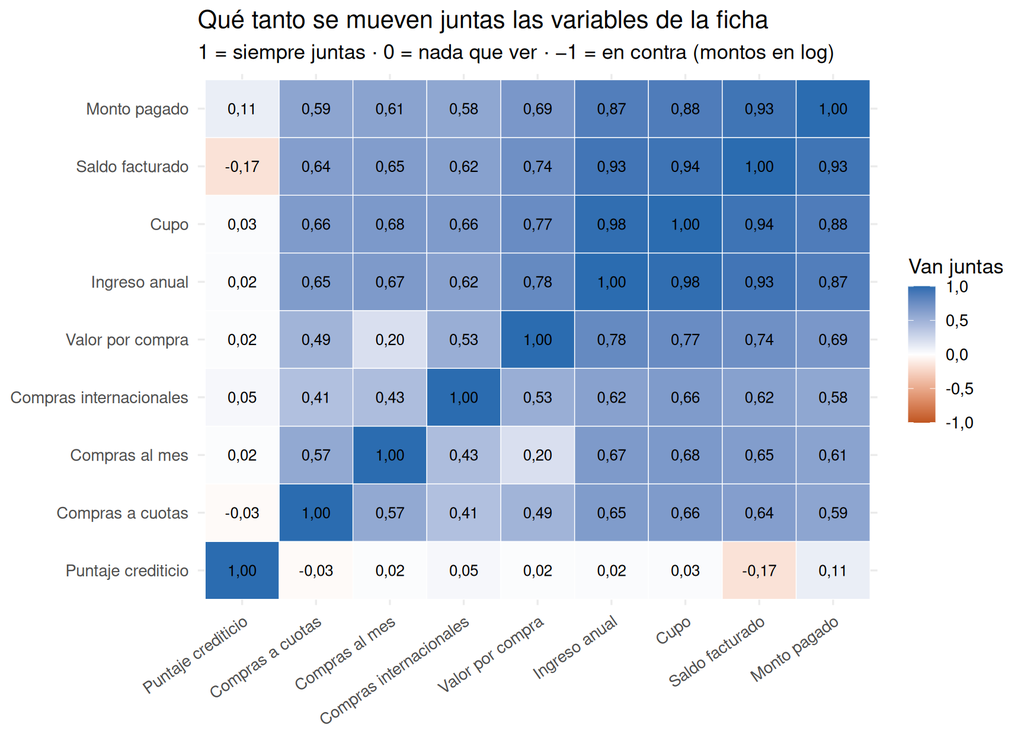

```r
R <- cor(X)
orden <- vars[hclust(as.dist(1 - abs(R)))$order]

as.data.frame(as.table(R)) |>
  mutate(Var1 = factor(etiqueta[as.character(Var1)], levels = etiqueta[orden]),
         Var2 = factor(etiqueta[as.character(Var2)], levels = etiqueta[orden])) |>
  ggplot(aes(Var1, Var2, fill = Freq)) +
  geom_tile(color = "white") +
  geom_text(aes(label = coma(Freq, 2)), size = 3.4) +
  scale_fill_gradient2(low = "#C05621", mid = "white", high = "#2B6CB0", limits = c(-1, 1),
                       name = "Van juntas", labels = function(x) coma(x, 1)) +
  labs(title = "Qué tanto se mueven juntas las variables de la ficha",
       subtitle = "1 = siempre juntas · 0 = nada que ver · −1 = en contra (montos en log)",
       x = NULL, y = NULL) +
  theme(axis.text.x = element_text(angle = 35, hjust = 1))
```

```r
fuera_diag <- R; diag(fuera_diag) <- NA
mayor <- apply(abs(fuera_diag), 1, max, na.rm = TRUE)
data.frame(variable = etiqueta[vars], su_mayor_correlacion = round(mayor, 2)) |>
  arrange(su_mayor_correlacion)
```

|  | variable | su_mayor_correlacion |
| --- | --- | --- |
| Credit_Score | Puntaje crediticio | 0.17 |
| EMI_Count | Compras a cuotas | 0.66 |
| International_Transactions | Compras internacionales | 0.66 |
| Monthly_Transactions | Compras al mes | 0.68 |
| Avg_Transaction_Value | Valor por compra | 0.78 |
| Payment_Amount | Monto pagado | 0.93 |
| Statement_Balance | Saldo facturado | 0.94 |
| Annual_Income | Ingreso anual | 0.98 |
| Credit_Limit | Cupo | 0.98 |

```r
dinero <- c("Annual_Income", "Credit_Limit", "Statement_Balance", "Payment_Amount")
uso <- c("EMI_Count", "Monthly_Transactions", "Avg_Transaction_Value", "International_Transactions")
```

> 👀 **Qué vemos:** ingreso, cupo, saldo facturado y monto pagado van casi pegados (0,87 a 0,98), las variables de uso de la tarjeta los siguen (0,58 a 0,78) y el puntaje va solo: con ninguna pasa de 0,17.

> 💼 **Qué significa para el cliente:** ocho de las nueve variables cuentan la misma historia, el tamaño del cliente, así que **sí tiene sentido resumirlas**; el puntaje, que es lo que la Gerencia más mira para el riesgo, no se parece a ninguna.

> ✅ **Qué decide el cliente:** puede resumir la ficha, pero debe comprobar que el resumen no deje por fuera el puntaje.

# 3 ¿Estandarizar?

```r
data.frame(variable = etiqueta[vars],
           desviacion_original = coma(sapply(credit[vars], sd), 2),
           desviacion_como_entra = sapply(X, sd)) |>
  arrange(desc(desviacion_como_entra)) |>
  mutate(desviacion_como_entra = coma(desviacion_como_entra, 2))
```

|  | variable | desviacion_original | desviacion_como_entra |
| --- | --- | --- | --- |
| Credit_Score | Puntaje crediticio | 68,44 | 68,44 |
| Monthly_Transactions | Compras al mes | 42,05 | 42,05 |
| EMI_Count | Compras a cuotas | 1,67 | 1,67 |
| Payment_Amount | Monto pagado | 453 396,64 | 1,27 |
| Credit_Limit | Cupo | 1 009 854,42 | 1,18 |
| Statement_Balance | Saldo facturado | 559 547,63 | 1,18 |
| Annual_Income | Ingreso anual | 1 407 257,48 | 0,80 |
| International_Transactions | Compras internacionales | 2,60 | 0,77 |
| Avg_Transaction_Value | Valor por compra | 779,59 | 0,62 |

```r
desv <- sapply(X, sd)
```

**Decisión, tomada antes de correr: estandarizamos.** Las variables vienen en unidades que no se pueden comparar: en las unidades originales, la desviación va de 1,67 (compras a cuotas) a 1 407 257 (ingreso, en rupias), y aun con el logaritmo va de 0,62 a 68,44 (el puntaje crediticio). Estandarizar es medir cada variable en «qué tan lejos está del cliente típico», para que ninguna mande solo por tener números grandes, y es lo que ya dejó definido el Módulo 11.

```r
pca_sin <- prcomp(X)                 # log, sin estandarizar
pca     <- prcomp(X, scale. = TRUE)  # log + scale (nuestra decisión, la del Módulo 11)

info_c1 <- function(p) 100 * p$sdev[1]^2 / sum(p$sdev^2)
manda   <- function(p) etiqueta[names(which.max(abs(p$rotation[, 1])))]

data.frame(
  version = c("Sin estandarizar", "Estandarizando"),
  la_C1_guarda_de_cada_100 = round(c(info_c1(pca_sin), info_c1(pca)), 1),
  variable_que_mas_pesa_en_C1 = c(manda(pca_sin), manda(pca)),
  su_peso = round(c(max(abs(pca_sin$rotation[, 1])), max(abs(pca$rotation[, 1]))), 2)
)
```

|  | version | la_C1_guarda_de_cada_100 | variable_que_mas_pesa_en_C1 | su_peso |
| --- | --- | --- | --- | --- |
| Credit_Score | Sin estandarizar | 72.5 | Puntaje crediticio | 1.00 |
| Credit_Limit | Estandarizando | 64.3 | Cupo | 0.41 |

> 👀 **Qué vemos:** sin estandarizar, la primera componente guarda 72,5 de cada 100 partes de la información, pero es casi solo puntaje crediticio; estandarizando guarda 64,3 y ninguna variable manda sola.

> 💼 **Qué significa para el cliente:** la cifra más alta no es la mejor, porque sin estandarizar la componente solo copia la variable de números más grandes.

> ✅ **Qué decide el cliente:** debe usar la versión estandarizada, y todo lo que sigue sale de ella.

# 4 Cuánta información guarda

```r
p <- length(vars)
reparto <- data.frame(componente  = factor(paste0("C", 1:p), levels = paste0("C", 1:p)),
                      de_cada_100 = 100 * pca$sdev^2 / sum(pca$sdev^2))
reparto$acumulado <- cumsum(reparto$de_cada_100)
k80 <- which(reparto$acumulado > 80)[1]
reparto |> mutate(across(c(de_cada_100, acumulado), ~ round(.x, 1)))
```

| componente | de_cada_100 | acumulado |
| --- | --- | --- |
| C1 | 64.3 | 64.3 |
| C2 | 11.7 | 76.0 |
| C3 | 9.3 | 85.3 |
| C4 | 6.3 | 91.6 |
| C5 | 5.0 | 96.6 |
| C6 | 2.2 | 98.8 |
| C7 | 0.9 | 99.8 |
| C8 | 0.2 | 99.9 |
| C9 | 0.1 | 100.0 |

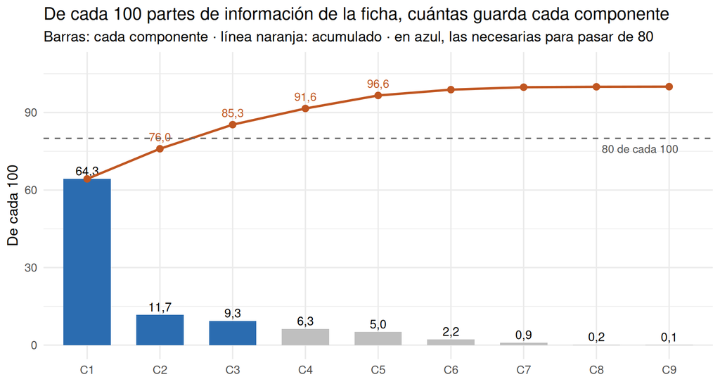

```r
ggplot(reparto, aes(componente, de_cada_100)) +
  geom_col(fill = ifelse(seq_len(p) <= k80, "#2B6CB0", "grey75"), width = 0.65) +
  geom_text(aes(label = coma(de_cada_100)), vjust = -0.4, size = 3.8) +
  geom_line(aes(y = acumulado, group = 1), color = "#C05621", linewidth = 1) +
  geom_point(aes(y = acumulado), color = "#C05621", size = 2.4) +
  geom_text(data = reparto[2:5, ], aes(y = acumulado, label = coma(acumulado)),
            vjust = -0.9, color = "#C05621", size = 3.6) +
  geom_hline(yintercept = 80, linetype = "dashed", color = "grey40") +
  annotate("text", x = p - 0.4, y = 76, label = "80 de cada 100", color = "grey30", size = 3.5) +
  scale_y_continuous(limits = c(0, 108)) +
  labs(title = "De cada 100 partes de información de la ficha, cuántas guarda cada componente",
       subtitle = "Barras: cada componente · línea naranja: acumulado · en azul, las necesarias para pasar de 80",
       x = NULL, y = "De cada 100")
```

> 👀 **Qué vemos:** la primera componente guarda 64,3 de cada 100 partes de la información; con dos se llega a 76,0 y con **3** se pasa de 80 (85,3).

> 💼 **Qué significa para el cliente:** *una sola componente resume 64 de cada 100 partes de la ficha de un cliente, y para no perder más de una quinta parte la Gerencia necesita mirar 3 números.*

> ✅ **Qué decide el cliente:** no debe reemplazar la ficha por un solo número sin ver antes qué hay en las otras 36 partes.

# 5 Qué mide cada una

En cada componente (C1, C2, C3), el **peso** dice cuánto manda cada variable.

```r
# El signo es arbitrario: lo fijamos para que la lectura sea cómoda.
# C1 positiva = más cupo; C2 positiva = peor puntaje; C3 positiva = compras de mayor valor.
signo <- c(sign(pca$rotation["Credit_Limit", 1]),
           -sign(pca$rotation["Credit_Score", 2]),
            sign(pca$rotation["Avg_Transaction_Value", 3]))
pesos <- sweep(pca$rotation[, 1:3], 2, signo, `*`)
puntaje_c <- sweep(pca$x[, 1:3], 2, signo, `*`)
round(pesos, 2)
```

```
##                             PC1   PC2   PC3
## Annual_Income              0.40 -0.02  0.04
## Credit_Limit               0.41 -0.02  0.03
## Statement_Balance          0.40  0.17  0.05
## Payment_Amount             0.38 -0.10  0.02
## EMI_Count                  0.30  0.07 -0.30
## Monthly_Transactions       0.29  0.01 -0.72
## Avg_Transaction_Value      0.32 -0.04  0.60
## International_Transactions 0.29 -0.09  0.18
## Credit_Score               0.00 -0.97 -0.07
```

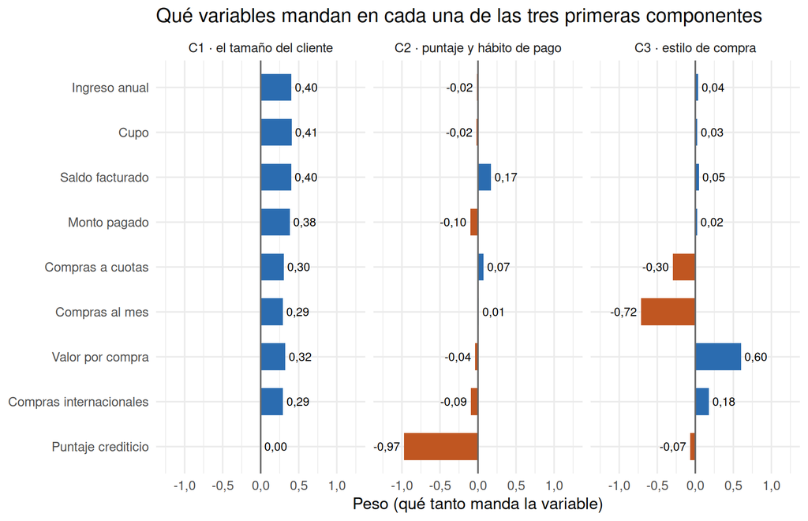

```r
nombres <- c(PC1 = "C1 · el tamaño del cliente",
             PC2 = "C2 · puntaje y hábito de pago",
             PC3 = "C3 · estilo de compra")
data.frame(pesos, variable = rownames(pesos)) |>
  pivot_longer(-variable, names_to = "componente", values_to = "peso") |>
  mutate(componente = factor(nombres[componente], levels = nombres),
         variable = factor(etiqueta[variable], levels = rev(etiqueta[vars]))) |>
  ggplot(aes(peso, variable, fill = peso > 0)) +
  geom_col(width = 0.6) +
  geom_vline(xintercept = 0, color = "grey40") +
  geom_text(aes(label = coma(peso, 2), hjust = ifelse(peso > 0, -0.15, 1.15)), size = 3.3) +
  facet_wrap(~ componente) +
  scale_fill_manual(values = c("#C05621", "#2B6CB0"), guide = "none") +
  scale_x_continuous(limits = c(-1.25, 1.25), labels = function(x) coma(x, 1)) +
  labs(title = "Qué variables mandan en cada una de las tres primeras componentes",
       x = "Peso (qué tanto manda la variable)", y = NULL)
```

Para confirmar los nombres miramos con qué se mueven `Payment_Ratio` (proporción pagada) y `Credit_Utilization` (uso del cupo), dos variables que no se usaron para armar las componentes:

```r
round(cor(puntaje_c, credit[suplementarias]), 2)
```

```
##     Payment_Ratio Credit_Utilization
## PC1          0.06               0.11
## PC2         -0.76               0.59
## PC3         -0.06               0.07
```

> 👀 **Qué vemos:** a la primera componente la mueven las variables en rupias (pesos de 0,38 a 0,41), la segunda casi solo el puntaje (-0,97), que va -0,76 con la proporción pagada, y la tercera enfrenta el valor por compra (0,60) con las compras al mes (-0,72).

> 💼 **Qué significa para el cliente:** los llamamos **tamaño del cliente** (sube con todo lo que gana, tiene y mueve), **puntaje y hábito de pago** (un puntaje bajo va con pagar poco de lo facturado) y **estilo de compra** (pocas compras caras o muchas pequeñas), nombres que ponemos nosotros al ver qué variables mandan, y el signo del peso es arbitrario.

> ✅ **Qué decide el cliente:** lo que la primera componente deja por fuera no es ruido sino el puntaje y el pago, así que no debe decidir el seguimiento mirando solo el tamaño.

# 6 El costo para su cliente

**El grupo que le importa a la Gerencia:** los clientes con **puntaje crediticio bajo** (el 20 % más bajo de la cartera), que son los que el buró señala como más riesgosos. Si decidiera con un solo número, mandaría a seguimiento al 20 % de clientes en un extremo de la componente de tamaño; para darle su mejor oportunidad, probamos los dos extremos y nos quedamos con el que encuentre más. Después hacemos lo mismo con la componente de puntaje y pago.

```r
corte <- quantile(credit$Credit_Score, 0.20)
riesgo <- credit$Credit_Score <= corte
en_el_20_alto <- function(s) s >= quantile(s, 0.80)

encuentra <- function(s) max(sum(riesgo & en_el_20_alto(s)), sum(riesgo & en_el_20_alto(-s)))

cobertura <- data.frame(
  decide_con = c("Solo C1 (tamaño)", "C2 (puntaje y pago)", "Al azar (referencia)"),
  clientes_de_riesgo = sum(riesgo),
  los_encuentra = c(encuentra(puntaje_c[, 1]), encuentra(puntaje_c[, 2]), round(0.2 * sum(riesgo)))
)
cobertura$se_le_escapan <- cobertura$clientes_de_riesgo - cobertura$los_encuentra
cobertura$de_cada_100_se_escapan <- round(100 * cobertura$se_le_escapan / cobertura$clientes_de_riesgo, 1)
cobertura
```

| decide_con | clientes_de_riesgo | los_encuentra | se_le_escapan | de_cada_100_se_escapan |
| --- | --- | --- | --- | --- |
| Solo C1 (tamaño) | 10046 | 2089 | 7957 | 79.2 |
| C2 (puntaje y pago) | 10046 | 9571 | 475 | 4.7 |
| Al azar (referencia) | 10046 | 2009 | 8037 | 80.0 |

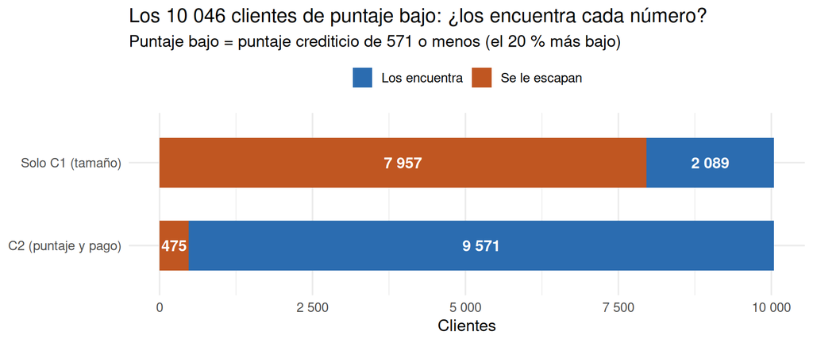

```r
cobertura[1:2, ] |>
  select(decide_con, `Los encuentra` = los_encuentra, `Se le escapan` = se_le_escapan) |>
  pivot_longer(-decide_con) |>
  mutate(decide_con = factor(decide_con, levels = rev(cobertura$decide_con[1:2]))) |>
  ggplot(aes(value, decide_con, fill = name)) +
  geom_col(width = 0.6) +
  geom_text(aes(label = miles(value)), position = position_stack(vjust = 0.5),
            color = "white", fontface = "bold", size = 4.3) +
  scale_fill_manual(values = c("#2B6CB0", "#C05621"), name = NULL) +
  scale_x_continuous(labels = miles) +
  labs(title = paste0("Los ", miles(sum(riesgo)), " clientes de puntaje bajo: ¿los encuentra cada número?"),
       subtitle = paste0("Puntaje bajo = puntaje crediticio de ", corte, " o menos (el 20 % más bajo)"),
       x = "Clientes", y = NULL) +
  theme(legend.position = "top")
```

> 👀 **Qué vemos:** de los 10 046 clientes con puntaje de 571 o menos, la componente de tamaño encuentra 2 089 y se le escapan 7 957 (79 de cada 100), casi lo mismo que al azar (2 009), mientras que la de puntaje y pago encuentra 9 571.

> 💼 **Qué significa para el cliente:** una lista por tamaño es casi sacar nombres de un sombrero y deja sin seguimiento a 79 de cada 100 clientes de puntaje bajo.

> ✅ **Qué decide el cliente:** no debe escoger a quién hacer seguimiento con la componente de tamaño.

**Una advertencia.** La segunda componente casi es el puntaje crediticio (pesa -0,97), así que encontrar con ella a los de puntaje bajo es, en parte, repetir la definición. Para comprobarlo con algo distinto repetimos la prueba con el 20 % de clientes que **paga la menor parte de lo facturado** (`Payment_Ratio`), una medida que no se usó para armar ninguna componente.

```r
corte_pago <- quantile(credit$Payment_Ratio, 0.20)
riesgo_pago <- credit$Payment_Ratio <= corte_pago
encuentra_pago <- function(s) max(sum(riesgo_pago & en_el_20_alto(s)),
                                  sum(riesgo_pago & en_el_20_alto(-s)))

cobertura_pago <- data.frame(
  decide_con = c("Solo C1 (tamaño)", "C2 (puntaje y pago)", "C3 (estilo de compra)", "Al azar (referencia)"),
  clientes_de_riesgo = sum(riesgo_pago),
  los_encuentra = c(encuentra_pago(puntaje_c[, 1]), encuentra_pago(puntaje_c[, 2]),
                    encuentra_pago(puntaje_c[, 3]), round(0.2 * sum(riesgo_pago)))
)
cobertura_pago$se_le_escapan <- cobertura_pago$clientes_de_riesgo - cobertura_pago$los_encuentra
cobertura_pago$de_cada_100_se_escapan <-
  round(100 * cobertura_pago$se_le_escapan / cobertura_pago$clientes_de_riesgo, 1)
cobertura_pago
```

| decide_con | clientes_de_riesgo | los_encuentra | se_le_escapan | de_cada_100_se_escapan |
| --- | --- | --- | --- | --- |
| Solo C1 (tamaño) | 10311 | 2401 | 7910 | 76.7 |
| C2 (puntaje y pago) | 10311 | 7090 | 3221 | 31.2 |
| C3 (estilo de compra) | 10311 | 2388 | 7923 | 76.8 |
| Al azar (referencia) | 10311 | 2062 | 8249 | 80.0 |

> 👀 **Qué vemos:** de los 10 311 clientes que pagan 0,55 o menos de lo facturado, la componente de tamaño encuentra 2 401 (al azar, 2 062), la de puntaje y pago 7 090 y la de estilo de compra 2 388.

> 💼 **Qué significa para el cliente:** la conclusión se mantiene sin usar el puntaje, aunque la componente de puntaje y pago deja escapar a 3 221 clientes que pagan poco.

> ✅ **Qué decide el cliente:** debe usar la componente de puntaje y pago para priorizar, sabiendo que no encuentra a todos.

```r
grandes <- en_el_20_alto(puntaje_c[, 1])
grandes_y_riesgosos <- grandes & riesgo
c(clientes_grandes_y_de_riesgo = sum(grandes_y_riesgosos),
  cupo_promedio_de_ellos       = round(mean(credit$Credit_Limit[grandes_y_riesgosos])),
  cupo_promedio_de_la_cartera  = round(mean(credit$Credit_Limit)),
  proporcion_pagada_de_ellos   = round(mean(credit$Payment_Ratio[grandes_y_riesgosos]), 2),
  proporcion_pagada_otros_grandes = round(mean(credit$Payment_Ratio[grandes & !riesgo]), 2))
```

```
##    clientes_grandes_y_de_riesgo          cupo_promedio_de_ellos
##                         1845.00                      2137005.00
##     cupo_promedio_de_la_cartera      proporcion_pagada_de_ellos
##                       709677.00                            0.47
## proporcion_pagada_otros_grandes
##                            0.86
```

> 👀 **Qué vemos:** 1 845 clientes están entre el 20 % más grande y los de puntaje bajo, con un cupo promedio de 2 137 005 rupias (cartera: 709 677) y una proporción pagada de 0,47, contra 0,86 de los demás grandes.

> 💼 **Qué significa para el cliente:** para la componente de tamaño son «los mejores clientes» y candidatos a más cupo, aunque tienen puntaje bajo y pagan mucho menos de lo que se les factura.

> ✅ **Qué decide el cliente:** un número no le basta, y debe reportar tamaño (cuánto dinero hay en juego) y puntaje y pago (a quién llamar), que juntos guardan 76,0 de cada 100 partes; la tercera componente no le hace falta para riesgo.

# 7 Lo que le entregamos a la Gerencia

- **Sí se puede resumir la ficha**, porque ocho de sus nueve variables cuentan casi la misma historia: el tamaño del cliente.
- **Pero una sola componente deja por fuera justo el puntaje y el hábito de pago.** Esa información va casi sola en la segunda componente.
- **En clientes, el costo es concreto:** de los 10 046 con puntaje bajo, la componente de tamaño deja por fuera 7 957. A los 1 845 clientes grandes con puntaje bajo los confunde con los mejores clientes.
- **La decisión:** reportar dos números, tamaño y puntaje con hábito de pago. El segundo es el que debe decidir la entrada al programa de seguimiento preventivo.